# IODS course project

# Week 5: Dimensionality reduction techniques

Making libraries available

```r
date()
```

```
## [1] "Sun Dec 12 17:30:52 2021"
```

```r
if (!require("pacman")) install.packages("pacman")
pacman::p_load(tidyverse, forcats, haven, janitor, psych, lm.beta, broom, writexl,sjstats, knitr, pwr, corrplot, tidyr, dplyr, ggplot2, GGally, knitr, png, FactoMineR)
library(knitr)
library(png)
library(corrplot)
library(tidyr)
library(dplyr)
library(ggplot2)
library(GGally)
library(FactoMineR)
```

This week we are learning about dimensionality reduction technique. The dataset in use is a combined and modified “human” dataset, which originates from United Nations Development Programme data of Human development index and Gender Equality. Here you can find more information of the data: http://hdr.undp.org/en/content/human-development-index-hdi

The variables are “Life.Exp” for Life expectancy at birth, “Edu.Exp” for Expected years of education, “GNI” for Gross National Income per capita, “Mat.Mor” for Maternal mortality ratio, “Ado.Birth” for Adolescent birth rate, “Parli.F” for Percent of Representation in Parliament, “Edu2.FM” for the ratio of Female and Male populations with secondary education in each country “Labo.FM” for the ratio of Female and Male populations labour force participation in each country.

```r
# load the data from my computer and telling R that the row names are in the first column
human <- read.csv("C:/Users/35840/OneDrive - University of Helsinki/IODS/IODS-project/data/human.csv", row.names = 1)

# explore the dataset
str(human)
```

```
## 'data.frame':    155 obs. of  8 variables:
##  $ Edu2.FM  : num  1.007 0.997 0.983 0.989 0.969 ...
##  $ Labo.FM  : num  0.891 0.819 0.825 0.884 0.829 ...
##  $ Edu.Exp  : num  17.5 20.2 15.8 18.7 17.9 16.5 18.6 16.5 15.9 19.2 ...
##  $ Life.Exp : num  81.6 82.4 83 80.2 81.6 80.9 80.9 79.1 82 81.8 ...
##  $ GNI      : num  65 42.3 56.4 44 45.4 ...
##  $ Mat.Mor  : int  4 6 6 5 6 7 9 28 11 8 ...
##  $ Ado.Birth: num  7.8 12.1 1.9 5.1 6.2 3.8 8.2 31 14.5 25.3 ...
##  $ Parli.F  : num  39.6 30.5 28.5 38 36.9 36.9 19.9 19.4 28.2 31.4 ...
```

```r
dim(human)
```

```
## [1] 155   8
```

```r
summary(human)
```

```
##     Edu2.FM          Labo.FM          Edu.Exp         Life.Exp
##  Min.   :0.1717   Min.   :0.1857   Min.   : 5.40   Min.   :49.00
##  1st Qu.:0.7264   1st Qu.:0.5984   1st Qu.:11.25   1st Qu.:66.30
##  Median :0.9375   Median :0.7535   Median :13.50   Median :74.20
##  Mean   :0.8529   Mean   :0.7074   Mean   :13.18   Mean   :71.65
##  3rd Qu.:0.9968   3rd Qu.:0.8535   3rd Qu.:15.20   3rd Qu.:77.25
##  Max.   :1.4967   Max.   :1.0380   Max.   :20.20   Max.   :83.50
##       GNI             Mat.Mor         Ado.Birth         Parli.F
##  Min.   :  1.123   Min.   :   1.0   Min.   :  0.60   Min.   : 0.00
##  1st Qu.:  5.275   1st Qu.:  11.5   1st Qu.: 12.65   1st Qu.:12.40
##  Median : 13.054   Median :  49.0   Median : 33.60   Median :19.30
##  Mean   : 46.496   Mean   : 149.1   Mean   : 47.16   Mean   :20.91
##  3rd Qu.: 27.256   3rd Qu.: 190.0   3rd Qu.: 71.95   3rd Qu.:27.95
##  Max.   :908.000   Max.   :1100.0   Max.   :204.80   Max.   :57.50
```

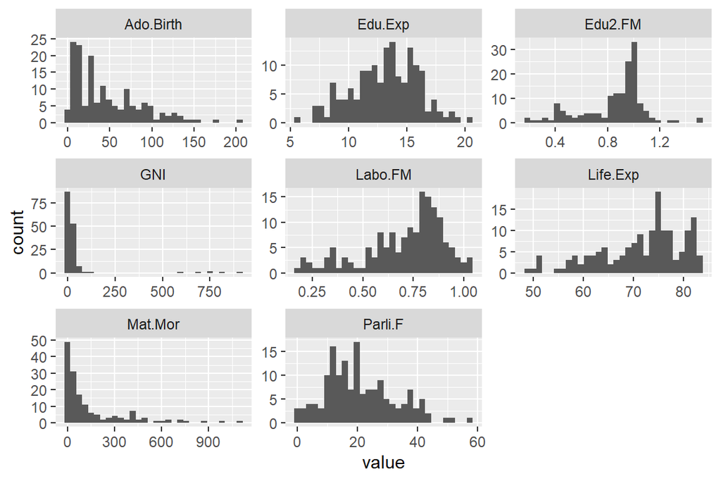

```r
# histograms
gather(human) %>% ggplot(aes(value)) + facet_wrap("key", scales = "free") + geom_histogram()
```

```r
# calculate the correlation matrix and round it
cor_matrix<-cor(human) %>% round(digits = 2)

# print the correlation matrix
cor_matrix
```

```
##           Edu2.FM Labo.FM Edu.Exp Life.Exp   GNI Mat.Mor Ado.Birth Parli.F
## Edu2.FM      1.00    0.01    0.59     0.58 -0.29   -0.66     -0.53    0.08
## Labo.FM      0.01    1.00    0.05    -0.14  0.15    0.24      0.12    0.25
## Edu.Exp      0.59    0.05    1.00     0.79 -0.24   -0.74     -0.70    0.21
## Life.Exp     0.58   -0.14    0.79     1.00 -0.23   -0.86     -0.73    0.17
## GNI         -0.29    0.15   -0.24    -0.23  1.00    0.44      0.31   -0.07
## Mat.Mor     -0.66    0.24   -0.74    -0.86  0.44    1.00      0.76   -0.09
## Ado.Birth   -0.53    0.12   -0.70    -0.73  0.31    0.76      1.00   -0.07
## Parli.F      0.08    0.25    0.21     0.17 -0.07   -0.09     -0.07    1.00
```

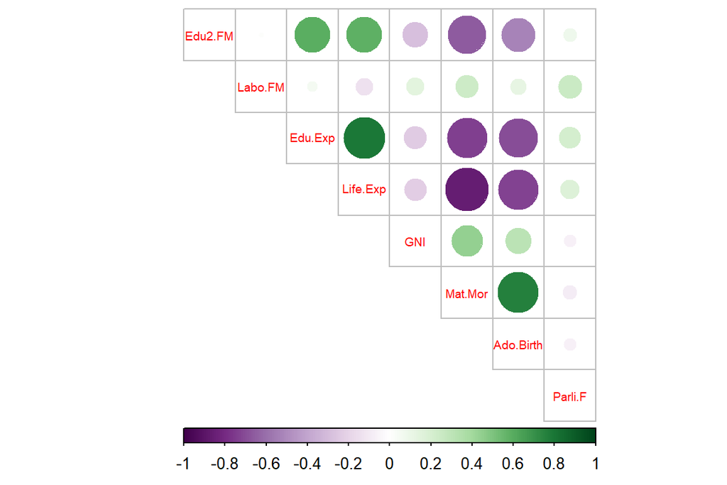

```r
# visualize the correlation matrix
corrplot(cor_matrix, method="circle", type="upper", cl.pos="b", tl.pos="d", tl.cex = 0.6,
         col = COL2('PRGn'))
```

It looks like there is very little correlation between the variables Parli.F and Labo.FM with the other variables. Most understandably there is strong correlation between Life.Exp and Edu.Exp, as we can assume that both life expectancy and years of secondary education are affected by general living standards and well-being. Accordingly, a strong negative correlation is shown between Mat.Mor and Life.Exp. GNI’s correlation with the variables is in general surprisingly weak, when we think that Gross National Income would play a role in the general living standards.

Next, we’ll perform a principal component analysis (PCA) to the non-standardized data:

```r
# principal component analysis (with the SVD method) and the variability captured by the principal components
pca_human <- prcomp(human)
summary(pca_human)
```

```
## Importance of components:
##                            PC1      PC2      PC3      PC4     PC5     PC6
## Standard deviation     227.566 121.2798 26.48071 11.47526 3.89773 1.60859
## Proportion of Variance   0.769   0.2184  0.01041  0.00196 0.00023 0.00004
## Cumulative Proportion    0.769   0.9874  0.99778  0.99974 0.99996 1.00000
##                           PC7    PC8
## Standard deviation     0.1915 0.1598
## Proportion of Variance 0.0000 0.0000
## Cumulative Proportion  1.0000 1.0000
```

The variation captured is noted on the line “Proportion of variance” and we can see that PC1 captures almost 77% of the variation and PC2 about 22%, which leaves only about 1% of the variation causes to the other components.

Let’s look at a biplot of the PC representation with the first two variables:

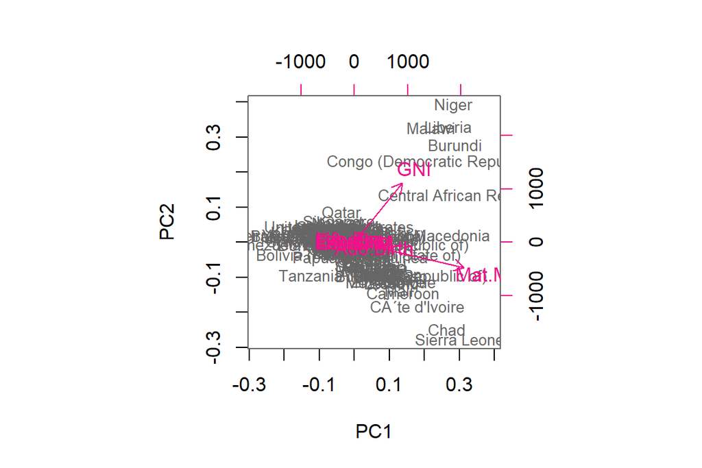

Non-Standardized dataset. Variables affecting the Human Development Index

```r
# draw a biplot of the principal component representation and the original variables
biplot(pca_human, choices = 1:2, cex = c(0.8, 1), col = c("grey40", "deeppink2"))
```

Now we’ll try that again but with standardized data:

```r
# standardize the variables
human_std <- scale(human)

# print out summaries of the standardized variables
summary(human_std)
```

```
##     Edu2.FM           Labo.FM           Edu.Exp           Life.Exp
##  Min.   :-2.8189   Min.   :-2.6247   Min.   :-2.7378   Min.   :-2.7188
##  1st Qu.:-0.5233   1st Qu.:-0.5484   1st Qu.:-0.6782   1st Qu.:-0.6425
##  Median : 0.3503   Median : 0.2316   Median : 0.1140   Median : 0.3056
##  Mean   : 0.0000   Mean   : 0.0000   Mean   : 0.0000   Mean   : 0.0000
##  3rd Qu.: 0.5958   3rd Qu.: 0.7350   3rd Qu.: 0.7126   3rd Qu.: 0.6717
##  Max.   : 2.6646   Max.   : 1.6632   Max.   : 2.4730   Max.   : 1.4218
##       GNI             Mat.Mor          Ado.Birth          Parli.F
##  Min.   :-0.3162   Min.   :-0.6992   Min.   :-1.1325   Min.   :-1.8203
##  1st Qu.:-0.2873   1st Qu.:-0.6496   1st Qu.:-0.8394   1st Qu.:-0.7409
##  Median :-0.2330   Median :-0.4726   Median :-0.3298   Median :-0.1403
##  Mean   : 0.0000   Mean   : 0.0000   Mean   : 0.0000   Mean   : 0.0000
##  3rd Qu.:-0.1341   3rd Qu.: 0.1932   3rd Qu.: 0.6030   3rd Qu.: 0.6127
##  Max.   : 6.0037   Max.   : 4.4899   Max.   : 3.8344   Max.   : 3.1850
```

```r
# perform principal component analysis (with the SVD method) and check variation
pca_human2 <- prcomp(human_std)
summary(pca_human2)
```

```
## Importance of components:
##                           PC1    PC2    PC3     PC4     PC5     PC6     PC7
## Standard deviation     1.9970 1.1465 0.9439 0.85645 0.69002 0.53246 0.46511
## Proportion of Variance 0.4985 0.1643 0.1114 0.09169 0.05952 0.03544 0.02704
## Cumulative Proportion  0.4985 0.6628 0.7742 0.86585 0.92536 0.96080 0.98784
##                            PC8
## Standard deviation     0.31184
## Proportion of Variance 0.01216
## Cumulative Proportion  1.00000
```

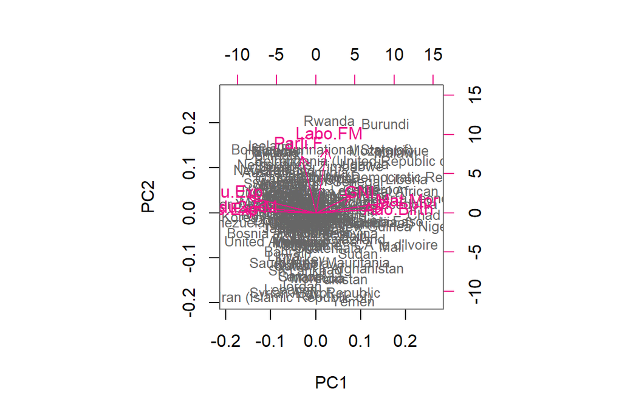

Standardized dataset. Variables affecting the Human Development Index

```r
# draw a biplot of the principal component representation and the original variables
biplot(pca_human2, choices = 1:2, cex = c(0.8, 1), col = c("grey40", "deeppink2"))
```

Now the variance captured by PC1 is only around 50% and PC2 around 16%, which evens out the variation caused by other components, while we are still able to say that the variation is mainly caused by the two first components. The results are different with standardized and non-standardized data. The non-standardized data mapped on the biplot only show the first two principal components, as they together explain almost all of the variance. Sub-saharan African countries are singled out. The standardized data analyzed with PCA on the other hand shows that more factors explain the variance. Northern Europe stands out as a cluster, explained by Parliamentary representation, ratio of F/M labour and expected years of secondary education.